# Plain vanilla recurrent neural networks in R: waves prediction

https://www.r-bloggers.com/plain-vanilla-recurrent-neural-networks-in-r-waves-prediction/

While continuing my study of neural networks and deep learning, I inevitably meet up with recurrent neural networks.

Recurrent neural networks (RNN) are a particular kind of neural networks usually very good at predicting sequences due to their inner working. If your task is to predict a sequence or a periodic signal, then using a RNN might be a good starting point. Plain vanilla RNN work fine but they have a little problem when trying to “keep in memory” events occured, say for instance, more than 20 steps back. The solution to this problem has been addressed with the development of a model called LSTM network. As far as I know, LSTM should usually be preferred to a plain vanilla RNN when possible as it yields better results.

In this post however, I am going to work on a plain vanilla RNN model. The reasons for doing this are two. First of all this is one of my first experience with RNN and I would like to get comfortable with them before going deeper; secondly, R provides a simple and very user friendly package named “rnn” for working with recurrent neural networks. I am going to dive in LSTM using MXNET and Tensorflow later.

Task description The task I am going to address is trying to predict a cosine from a noisy sine wave. Here below you can see the plot of the predictor X sequence and the Y sequence to be predicted.

```r
# Clear workspace
rm(list=ls())
# Load libraries
require(rnn)
# Set seed for reproducibility purposes
set.seed(10)
# Set frequency
f <- 5
w <- 2*pi*f
# Create sequences
t <- seq(0.005,2,by=0.005)
x <- sin(t*w) + rnorm(200, 0, 0.25)
y <- cos(t*w)
# Samples of 20 time series
X <- matrix(x, nrow = 40)
Y <- matrix(y, nrow = 40)
# Plot noisy waves
plot(as.vector(X), col='blue', type='l', ylab = "X,Y", main = "Noisy waves")
lines(as.vector(Y), col = "red")
```

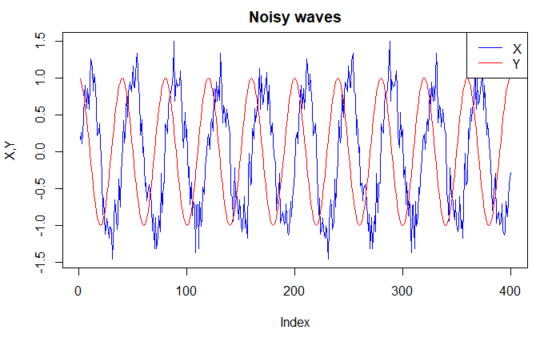

```r
legend("topright", c("X", "Y"), col = c("blue","red"), lty = c(1,1), lwd = c(1,1))
```

```r
# Standardize in the interval 0 - 1
X <- (X - min(X)) / (max(X) - min(X))
Y <- (Y - min(Y)) / (max(Y) - min(Y))
# Transpose
X <- t(X)
Y <- t(Y)
# Training-testing sets
train <- 1:8
test <- 9:10
```

```r
# Train model. Keep out the last two sequences.
model <- trainr(Y = Y[train,],
                X = X[train,],
                learningrate = 0.05,
                hidden_dim = 16,
                numepochs = 1500)
```

```
Trained epoch: 1 - Learning rate: 0.05
Epoch error: 13.2683505531601
Trained epoch: 2 - Learning rate: 0.05
Epoch error: 12.9071342083457
Trained epoch: 3 - Learning rate: 0.05
Epoch error: 12.8801988378626
Trained epoch: 4 - Learning rate: 0.05
Epoch error: 12.8507792104483
Trained epoch: 5 - Learning rate: 0.05
Epoch error: 12.8164718162603
Trained epoch: 6 - Learning rate: 0.05
Epoch error: 12.777432595954
Trained epoch: 7 - Learning rate: 0.05
Epoch error: 12.7335008193418
Trained epoch: 8 - Learning rate: 0.05
Epoch error: 12.6800525681664
Trained epoch: 9 - Learning rate: 0.05
Epoch error: 12.6257543758761
Trained epoch: 10 - Learning rate: 0.05
Epoch error: 12.5555842983255
Trained epoch: 11 - Learning rate: 0.05
Epoch error: 12.489131187924
Trained epoch: 12 - Learning rate: 0.05
Epoch error: 12.4156893899805
Trained epoch: 13 - Learning rate: 0.05
Epoch error: 12.3408373298541
Trained epoch: 14 - Learning rate: 0.05
Epoch error: 12.2684690069382
Trained epoch: 15 - Learning rate: 0.05
Epoch error: 12.1937523607287
Trained epoch: 16 - Learning rate: 0.05
Epoch error: 12.1254795775111
Trained epoch: 17 - Learning rate: 0.05
Epoch error: 12.0370926255001
Trained epoch: 18 - Learning rate: 0.05
Epoch error: 11.9571734675633
Trained epoch: 19 - Learning rate: 0.05
Epoch error: 11.8656391000642
Trained epoch: 20 - Learning rate: 0.05
Epoch error: 11.762799999273
```

[output cut: 2945 more lines]

```
Epoch error: 0.556852015287141
Trained epoch: 1494 - Learning rate: 0.05
Epoch error: 0.545592741086712
Trained epoch: 1495 - Learning rate: 0.05
Epoch error: 0.63633353225294
Trained epoch: 1496 - Learning rate: 0.05
Epoch error: 0.60572149126215
Trained epoch: 1497 - Learning rate: 0.05
Epoch error: 0.687466290190488
Trained epoch: 1498 - Learning rate: 0.05
Epoch error: 0.57879775451569
Trained epoch: 1499 - Learning rate: 0.05
Epoch error: 0.715884699615313
Trained epoch: 1500 - Learning rate: 0.05
Epoch error: 0.90128765892305
```

```r
# Predicted values
Yp <- predictr(model, X)
# Plot predicted vs actual. Training set + testing set
plot(as.vector(t(Y)), col = 'red', type = 'l', main = "Actual vs predicted", ylab = "Y,Yp")
lines(as.vector(t(Yp)), type = 'l', col = 'blue')
```

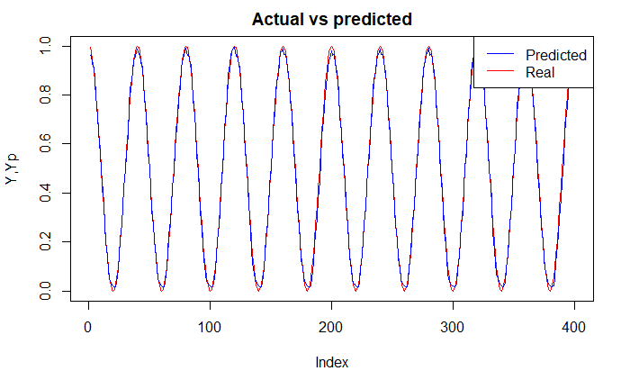

```r
legend("topright", c("Predicted", "Real"), col = c("blue","red"), lty = c(1,1), lwd = c(1,1))
```

```r
# Plot predicted vs actual. Testing set only.
plot(as.vector(t(Y[test,])), col = 'red', type='l', main = "Actual vs predicted: testing set", ylab = "Y,Yp")
lines(as.vector(t(Yp[test,])), type = 'l', col = 'blue')
```

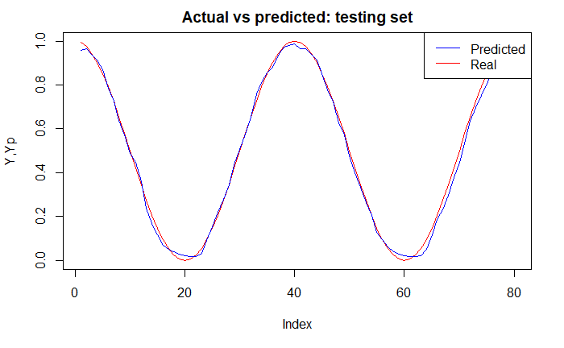

```r
legend("topright", c("Predicted", "Real"), col = c("blue","red"), lty = c(1,1), lwd = c(1,1))
```